# How could Olist increase its profit?

## Snapshot of current company PL in BRL

|  | + | - |
| --- | --- | --- |
| Revenue (Sales and Subscription) | 2785818 | 0 |
| Reputation Cost (Review Score) |  | 1976650 |
| IT Cost (Fixed and Variable) |  | 999999 |
| Total Cost |  | 2976649 |
| Net Profit (Revenue - Total Cost) |  | -190831 |
| Profit Margin |  | -7% |

## Recalculation of profit and margin by removing sellers

Lets remove sellers one by one starting from the least profitable and see what happens to company profit and margins

## Our findings in a graph

We call our new profit and margin hypothetical profit and margin

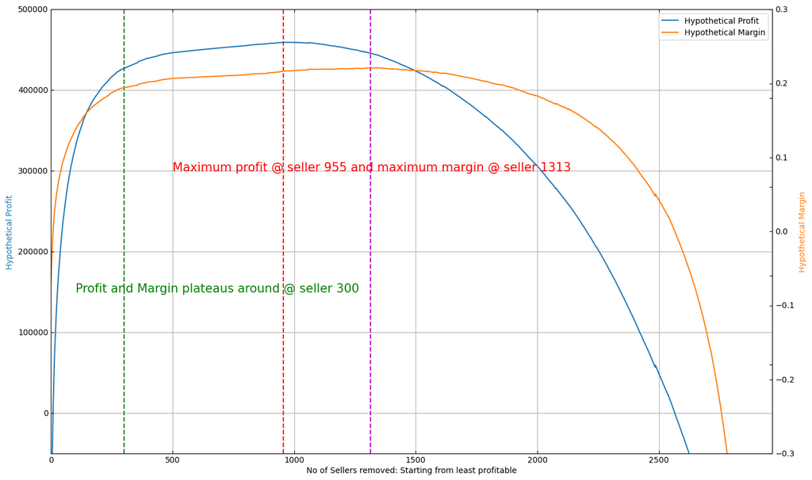

Findings:

1 ) We reach maximum profit when we stop working with least profitable 955 sellers.

2 ) We reach maximum profit margin when we stop working with least profitable 1313 sellers.

Suggestions:

1 ) Conservative approach: stop working with least profitable 300 sellers or find ways to penalize them with additional costs. Keep other sellers as we may find ways to profit from them. Also we don't want to decrease order volume.

2 ) Between seller 955 and 1313 revenues drop faster than profit which increases profit margins

## Properties of sellers (Worst 300 versus Best 300)

```
wait_time            14.429755
months_on_olist       8.723333
review_score_x        3.437748
freight_value      3050.976000
profits           -1739.931723
dtype: float64
```

```
wait_time            12.726909
months_on_olist      14.786667
review_score_x        4.218829
freight_value      1809.979367
profits            2040.269977
dtype: float64
```

Findings:

1 ) Bad sellers have longer average wait time.

2 ) Bad sellers are recently listed on Olist compared to best sellers.

3 ) Bad sellers have lower average review score

4 ) Average freight value tends to be higher for bad sellers.

Suggestions:

1 ) Introduce additional fee based on wait time to penalize bad sellers.

2 ) Be more selective with new listings.

3 ) Introduce additional fee based on review score to penalize bad sellers.

### Worst 300 sellers by their location

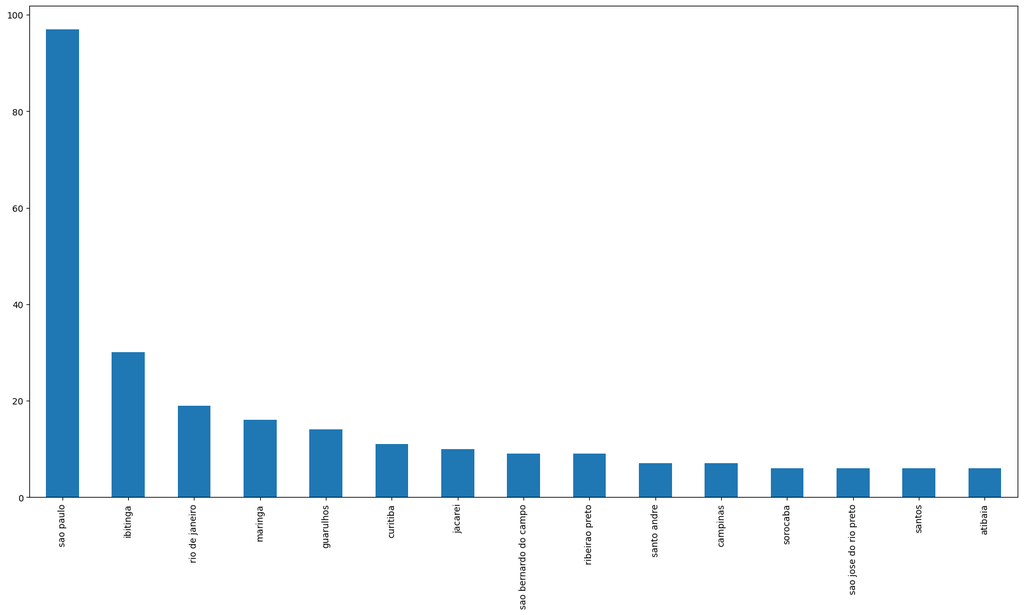

## Impact of dropping 300 sellers on order volume

```
seller_id    6560211a19b47992c3666cc44a7e94c01f50f920176fa8...
n_orders                                                 44407
quantity                                                 51672
profits                                            -521979.517
dtype: object
```

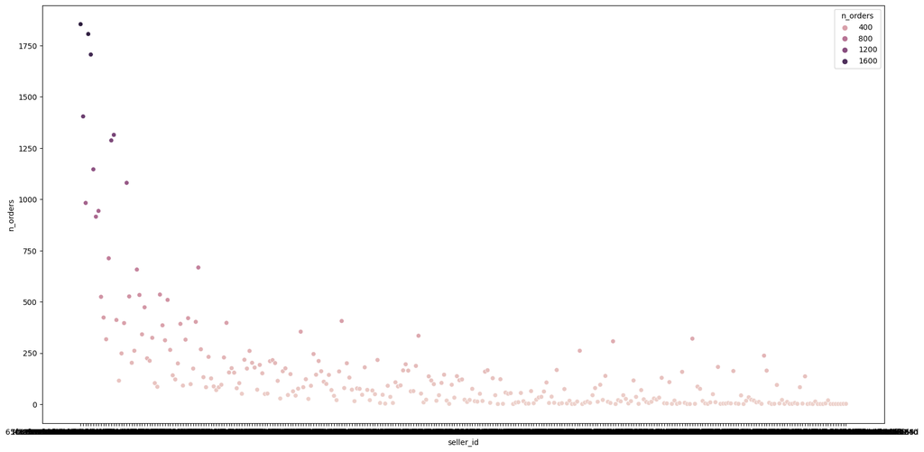

Finding:

Worst sellers have higher order volume.

Order volume impact will be higher at first when removing bad sellers.

Suggestion :

Start with worst customers and make reassesments along the way. Data will change by time.

### Good luck to the CEO :) End of presentation.